# Risk Factor Analysis

## Outcome Variable

**Outcome Variable:** pers_wasted624

## Predictor Variables

**Intervention Variable:** ever_underweight06

**Adjustment Set:**

- sex
- arm
- enstunt
- month
- brthmon
- vagbrth
- single
- W_gagebrth
- W_birthwt
- W_birthlen
- W_mage
- W_mhtcm
- W_meducyrs
- W_feducyrs
- W_parity
- delta_month
- delta_brthmon
- delta_vagbrth
- delta_single
- delta_W_gagebrth
- delta_W_birthwt
- delta_W_birthlen
- delta_W_mage
- delta_W_mhtcm
- delta_W_meducyrs
- delta_W_feducyrs
- delta_W_parity

## Stratifying Variables

The analysis was stratified on these variable(s):

- studyid
- country

## Data Summary

| studyid | country | ever_underweight06 | pers_wasted624 | n_cell | n |
| --- | --- | --- | --- | --- | --- |
| ki0047075b-MAL-ED | BANGLADESH | 0 | 0 | 161 | 239 |
| ki0047075b-MAL-ED | BANGLADESH | 0 | 1 | 5 | 239 |
| ki0047075b-MAL-ED | BANGLADESH | 1 | 0 | 60 | 239 |
| ki0047075b-MAL-ED | BANGLADESH | 1 | 1 | 13 | 239 |
| ki0047075b-MAL-ED | BRAZIL | 0 | 0 | 188 | 202 |
| ki0047075b-MAL-ED | BRAZIL | 0 | 1 | 2 | 202 |
| ki0047075b-MAL-ED | BRAZIL | 1 | 0 | 12 | 202 |
| ki0047075b-MAL-ED | BRAZIL | 1 | 1 | 0 | 202 |
| ki0047075b-MAL-ED | INDIA | 0 | 0 | 142 | 234 |
| ki0047075b-MAL-ED | INDIA | 0 | 1 | 1 | 234 |
| ki0047075b-MAL-ED | INDIA | 1 | 0 | 64 | 234 |
| ki0047075b-MAL-ED | INDIA | 1 | 1 | 27 | 234 |
| ki0047075b-MAL-ED | NEPAL | 0 | 0 | 197 | 234 |
| ki0047075b-MAL-ED | NEPAL | 0 | 1 | 0 | 234 |
| ki0047075b-MAL-ED | NEPAL | 1 | 0 | 35 | 234 |
| ki0047075b-MAL-ED | NEPAL | 1 | 1 | 2 | 234 |
| ki0047075b-MAL-ED | PERU | 0 | 0 | 222 | 264 |
| ki0047075b-MAL-ED | PERU | 0 | 1 | 1 | 264 |
| ki0047075b-MAL-ED | PERU | 1 | 0 | 40 | 264 |
| ki0047075b-MAL-ED | PERU | 1 | 1 | 1 | 264 |
| ki0047075b-MAL-ED | SOUTH AFRICA | 0 | 0 | 218 | 258 |
| ki0047075b-MAL-ED | SOUTH AFRICA | 0 | 1 | 0 | 258 |
| ki0047075b-MAL-ED | SOUTH AFRICA | 1 | 0 | 38 | 258 |
| ki0047075b-MAL-ED | SOUTH AFRICA | 1 | 1 | 2 | 258 |
| ki0047075b-MAL-ED | TANZANIA, UNITED REPUBLIC OF | 0 | 0 | 206 | 244 |
| ki0047075b-MAL-ED | TANZANIA, UNITED REPUBLIC OF | 0 | 1 | 0 | 244 |
| ki0047075b-MAL-ED | TANZANIA, UNITED REPUBLIC OF | 1 | 0 | 38 | 244 |
| ki0047075b-MAL-ED | TANZANIA, UNITED REPUBLIC OF | 1 | 1 | 0 | 244 |
| ki1000108-CMC-V-BCS-2002 | INDIA | 0 | 0 | 186 | 373 |
| ki1000108-CMC-V-BCS-2002 | INDIA | 0 | 1 | 4 | 373 |

[output cut: 118 more lines]

The following strata were considered:

- studyid: ki0047075b-MAL-ED, country: BANGLADESH
- studyid: ki0047075b-MAL-ED, country: BRAZIL
- studyid: ki0047075b-MAL-ED, country: INDIA
- studyid: ki0047075b-MAL-ED, country: NEPAL
- studyid: ki0047075b-MAL-ED, country: PERU
- studyid: ki0047075b-MAL-ED, country: SOUTH AFRICA
- studyid: ki0047075b-MAL-ED, country: TANZANIA, UNITED REPUBLIC OF
- studyid: ki1000108-CMC-V-BCS-2002, country: INDIA
- studyid: ki1000108-IRC, country: INDIA
- studyid: ki1000109-EE, country: PAKISTAN
- studyid: ki1000109-ResPak, country: PAKISTAN
- studyid: ki1000304-VITAMIN-A, country: INDIA
- studyid: ki1000304b-SAS-CompFeed, country: INDIA
- studyid: ki1000304b-SAS-FoodSuppl, country: INDIA
- studyid: ki1017093-NIH-Birth, country: BANGLADESH
- studyid: ki1017093b-PROVIDE, country: BANGLADESH
- studyid: ki1017093c-NIH-Crypto, country: BANGLADESH
- studyid: ki1066203-TanzaniaChild2, country: TANZANIA, UNITED REPUBLIC OF
- studyid: ki1101329-Keneba, country: GAMBIA
- studyid: ki1112895-Burkina Faso Zn, country: BURKINA FASO
- studyid: ki1112895-Guatemala BSC, country: GUATEMALA
- studyid: ki1113344-GMS-Nepal, country: NEPAL
- studyid: ki1114097-CMIN, country: BANGLADESH
- studyid: ki1114097-CMIN, country: BRAZIL
- studyid: ki1114097-CMIN, country: GUINEA-BISSAU
- studyid: ki1114097-CMIN, country: PERU
- studyid: ki1114097-CONTENT, country: PERU
- studyid: ki1119695-PROBIT, country: BELARUS
- studyid: ki1126311-ZVITAMBO, country: ZIMBABWE
- studyid: ki1135781-COHORTS, country: GUATEMALA
- studyid: ki1135781-COHORTS, country: INDIA
- studyid: ki1135781-COHORTS, country: PHILIPPINES
- studyid: ki1148112-iLiNS-DOSE, country: MALAWI
- studyid: ki1148112-iLiNS-DYAD-M, country: MALAWI
- studyid: ki1148112-LCNI-5, country: MALAWI
- studyid: kiGH5241-JiVitA-3, country: BANGLADESH
- studyid: kiGH5241-JiVitA-4, country: BANGLADESH

### Dropped Strata

Some strata were dropped due to rare outcomes:

- studyid: ki0047075b-MAL-ED, country: BRAZIL
- studyid: ki0047075b-MAL-ED, country: INDIA
- studyid: ki0047075b-MAL-ED, country: NEPAL
- studyid: ki0047075b-MAL-ED, country: PERU
- studyid: ki0047075b-MAL-ED, country: SOUTH AFRICA
- studyid: ki0047075b-MAL-ED, country: TANZANIA, UNITED REPUBLIC OF
- studyid: ki1000108-CMC-V-BCS-2002, country: INDIA
- studyid: ki1000109-EE, country: PAKISTAN
- studyid: ki1112895-Burkina Faso Zn, country: BURKINA FASO
- studyid: ki1112895-Guatemala BSC, country: GUATEMALA
- studyid: ki1114097-CMIN, country: BANGLADESH
- studyid: ki1114097-CMIN, country: BRAZIL
- studyid: ki1114097-CMIN, country: PERU
- studyid: ki1114097-CONTENT, country: PERU
- studyid: ki1148112-LCNI-5, country: MALAWI

## Methods Detail

We’re interested in the causal parameters $E[Y_a]$ for all values of $a \in \mathcal{A}$. These parameters represent the mean outcome if, possibly contrary to fact, we intervened to set all units to have $A=a$. Under the randomization and positivity assumptions, these are identified by the statistical parameters $\psi_a=E_W[E_{Y|A,W}(Y|A=a,W)]$. In addition, we’re interested in the mean of $Y$, $E[Y]$ under no intervention (the observed mean). We will estimate these parameters by using SuperLearner to fit the relevant likelihood factors – $E_{Y|A,W}(Y|A=a,W)$ and $p(A=a|W)$, and then updating our likelihood fit using a joint TMLE.

For unadjusted analyses ($W=\{\}$), initial likelihoods were estimated using Lrnr_glm to estimate the simple $E(Y|A)$ and Lrnr_mean to estimate $p(A)$. For adjusted analyses, a small library containing Lrnr_glmnet, Lrnr_xgboost, and Lrnr_mean was used.

Having estimated these parameters, we will then use the delta method to estimate relative risks and attributable risks relative to a prespecified baseline level of $A$.

# Results Detail

## Results Plots

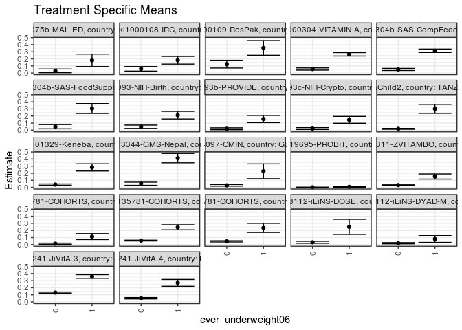

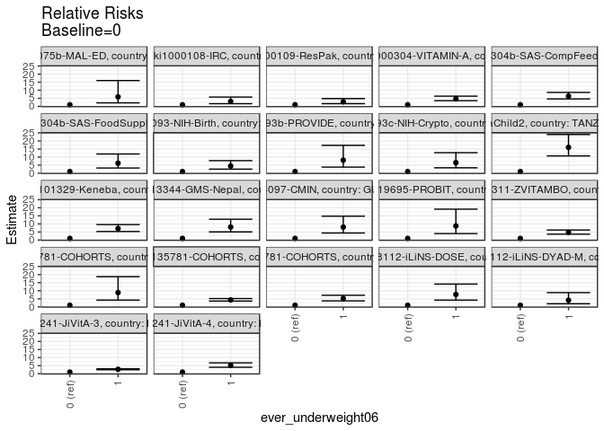

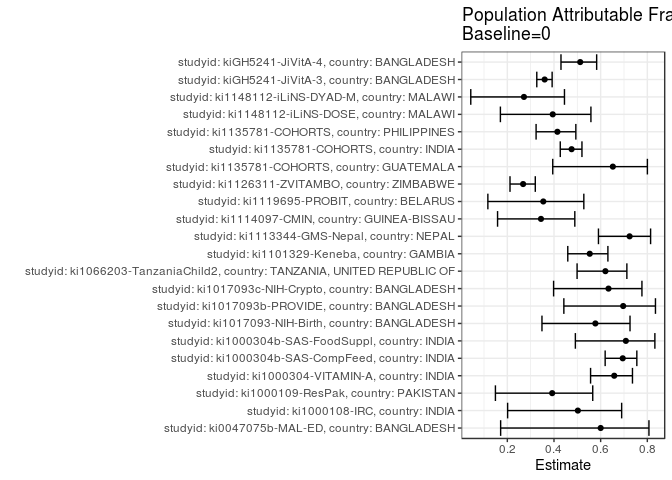

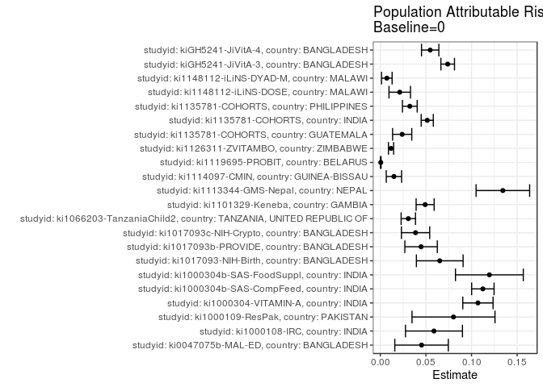

## Results Table

### Parameter: TSM

| studyid | country | intervention_level | baseline_level | estimate | ci_lower | ci_upper |
| --- | --- | --- | --- | --- | --- | --- |
| ki0047075b-MAL-ED | BANGLADESH | 0 | NA | 0.0301205 | 0.0040653 | 0.0561757 |
| ki0047075b-MAL-ED | BANGLADESH | 1 | NA | 0.1780822 | 0.0901351 | 0.2660293 |
| ki1000108-IRC | INDIA | 0 | NA | 0.0582565 | 0.0261737 | 0.0903392 |
| ki1000108-IRC | INDIA | 1 | NA | 0.1796357 | 0.1256910 | 0.2335803 |
| ki1000109-ResPak | PAKISTAN | 0 | NA | 0.1243033 | 0.0695902 | 0.1790164 |
| ki1000109-ResPak | PAKISTAN | 1 | NA | 0.3535110 | 0.2497207 | 0.4573014 |
| ki1000304-VITAMIN-A | INDIA | 0 | NA | 0.0555797 | 0.0402837 | 0.0708757 |
| ki1000304-VITAMIN-A | INDIA | 1 | NA | 0.2633743 | 0.2391494 | 0.2875991 |
| ki1000304b-SAS-CompFeed | INDIA | 0 | NA | 0.0494278 | 0.0346995 | 0.0641561 |
| ki1000304b-SAS-CompFeed | INDIA | 1 | NA | 0.3133709 | 0.2893911 | 0.3373507 |
| ki1000304b-SAS-FoodSuppl | INDIA | 0 | NA | 0.0493040 | 0.0191495 | 0.0794586 |
| ki1000304b-SAS-FoodSuppl | INDIA | 1 | NA | 0.3056972 | 0.2363372 | 0.3750572 |
| ki1017093-NIH-Birth | BANGLADESH | 0 | NA | 0.0476898 | 0.0237192 | 0.0716603 |
| ki1017093-NIH-Birth | BANGLADESH | 1 | NA | 0.2110166 | 0.1568272 | 0.2652060 |
| ki1017093b-PROVIDE | BANGLADESH | 0 | NA | 0.0194647 | 0.0060975 | 0.0328319 |
| ki1017093b-PROVIDE | BANGLADESH | 1 | NA | 0.1573604 | 0.1064694 | 0.2082514 |
| ki1017093c-NIH-Crypto | BANGLADESH | 0 | NA | 0.0223266 | 0.0094402 | 0.0352130 |
| ki1017093c-NIH-Crypto | BANGLADESH | 1 | NA | 0.1460274 | 0.0974844 | 0.1945703 |
| ki1066203-TanzaniaChild2 | TANZANIA, UNITED REPUBLIC OF | 0 | NA | 0.0187739 | 0.0123261 | 0.0252217 |
| ki1066203-TanzaniaChild2 | TANZANIA, UNITED REPUBLIC OF | 1 | NA | 0.3008895 | 0.2375749 | 0.3642040 |
| ki1101329-Keneba | GAMBIA | 0 | NA | 0.0396646 | 0.0302365 | 0.0490928 |
| ki1101329-Keneba | GAMBIA | 1 | NA | 0.2822114 | 0.2311366 | 0.3332861 |
| ki1113344-GMS-Nepal | NEPAL | 0 | NA | 0.0511981 | 0.0285938 | 0.0738025 |
| ki1113344-GMS-Nepal | NEPAL | 1 | NA | 0.4131937 | 0.3470536 | 0.4793339 |
| ki1114097-CMIN | GUINEA-BISSAU | 0 | NA | 0.0283802 | 0.0169546 | 0.0398057 |
| ki1114097-CMIN | GUINEA-BISSAU | 1 | NA | 0.2276384 | 0.1230004 | 0.3322765 |
| ki1119695-PROBIT | BELARUS | 0 | NA | 0.0007852 | 0.0000497 | 0.0015207 |
| ki1119695-PROBIT | BELARUS | 1 | NA | 0.0068552 | 0.0013591 | 0.0123513 |
| ki1126311-ZVITAMBO | ZIMBABWE | 0 | NA | 0.0321264 | 0.0285365 | 0.0357163 |
| ki1126311-ZVITAMBO | ZIMBABWE | 1 | NA | 0.1531920 | 0.1167383 | 0.1896457 |
| ki1135781-COHORTS | GUATEMALA | 0 | NA | 0.0127660 | 0.0044746 | 0.0210573 |
| ki1135781-COHORTS | GUATEMALA | 1 | NA | 0.1131222 | 0.0713399 | 0.1549045 |
| ki1135781-COHORTS | INDIA | 0 | NA | 0.0567594 | 0.0507167 | 0.0628021 |
| ki1135781-COHORTS | INDIA | 1 | NA | 0.2443431 | 0.2089499 | 0.2797363 |
| ki1135781-COHORTS | PHILIPPINES | 0 | NA | 0.0456493 | 0.0371523 | 0.0541463 |
| ki1135781-COHORTS | PHILIPPINES | 1 | NA | 0.2360496 | 0.1719360 | 0.3001631 |
| ki1148112-iLiNS-DOSE | MALAWI | 0 | NA | 0.0326430 | 0.0184720 | 0.0468141 |
| ki1148112-iLiNS-DOSE | MALAWI | 1 | NA | 0.2508149 | 0.1437798 | 0.3578500 |
| ki1148112-iLiNS-DYAD-M | MALAWI | 0 | NA | 0.0191412 | 0.0103699 | 0.0279124 |
| ki1148112-iLiNS-DYAD-M | MALAWI | 1 | NA | 0.0789070 | 0.0307770 | 0.1270370 |
| kiGH5241-JiVitA-3 | BANGLADESH | 0 | NA | 0.1313324 | 0.1233535 | 0.1393113 |
| kiGH5241-JiVitA-3 | BANGLADESH | 1 | NA | 0.3579688 | 0.3320416 | 0.3838959 |
| kiGH5241-JiVitA-4 | BANGLADESH | 0 | NA | 0.0520173 | 0.0422277 | 0.0618069 |
| kiGH5241-JiVitA-4 | BANGLADESH | 1 | NA | 0.2688806 | 0.2208696 | 0.3168916 |

### Parameter: E(Y)

| studyid | country | intervention_level | baseline_level | estimate | ci_lower | ci_upper |
| --- | --- | --- | --- | --- | --- | --- |
| ki0047075b-MAL-ED | BANGLADESH | NA | NA | 0.0753138 | 0.0417869 | 0.1088408 |
| ki1000108-IRC | INDIA | NA | NA | 0.1170732 | 0.0859146 | 0.1482317 |
| ki1000109-ResPak | PAKISTAN | NA | NA | 0.2045455 | 0.1511224 | 0.2579685 |
| ki1000304-VITAMIN-A | INDIA | NA | NA | 0.1626016 | 0.1492881 | 0.1759151 |
| ki1000304b-SAS-CompFeed | INDIA | NA | NA | 0.1618625 | 0.1426768 | 0.1810483 |
| ki1000304b-SAS-FoodSuppl | INDIA | NA | NA | 0.1689008 | 0.1308276 | 0.2069740 |
| ki1017093-NIH-Birth | BANGLADESH | NA | NA | 0.1128405 | 0.0854611 | 0.1402198 |
| ki1017093b-PROVIDE | BANGLADESH | NA | NA | 0.0641447 | 0.0446535 | 0.0836359 |
| ki1017093c-NIH-Crypto | BANGLADESH | NA | NA | 0.0609418 | 0.0434802 | 0.0784034 |
| ki1066203-TanzaniaChild2 | TANZANIA, UNITED REPUBLIC OF | NA | NA | 0.0494534 | 0.0397554 | 0.0591514 |
| ki1101329-Keneba | GAMBIA | NA | NA | 0.0887872 | 0.0768581 | 0.1007163 |
| ki1113344-GMS-Nepal | NEPAL | NA | NA | 0.1855670 | 0.1539560 | 0.2171780 |
| ki1114097-CMIN | GUINEA-BISSAU | NA | NA | 0.0432802 | 0.0298127 | 0.0567476 |
| ki1119695-PROBIT | BELARUS | NA | NA | 0.0012159 | 0.0002433 | 0.0021885 |
| ki1126311-ZVITAMBO | ZIMBABWE | NA | NA | 0.0438689 | 0.0395328 | 0.0482049 |
| ki1135781-COHORTS | GUATEMALA | NA | NA | 0.0367171 | 0.0245975 | 0.0488367 |
| ki1135781-COHORTS | INDIA | NA | NA | 0.1082022 | 0.1003643 | 0.1160400 |
| ki1135781-COHORTS | PHILIPPINES | NA | NA | 0.0779833 | 0.0679723 | 0.0879943 |
| ki1148112-iLiNS-DOSE | MALAWI | NA | NA | 0.0539216 | 0.0384151 | 0.0694281 |
| ki1148112-iLiNS-DYAD-M | MALAWI | NA | NA | 0.0262664 | 0.0166615 | 0.0358713 |
| kiGH5241-JiVitA-3 | BANGLADESH | NA | NA | 0.2052021 | 0.1976666 | 0.2127376 |
| kiGH5241-JiVitA-4 | BANGLADESH | NA | NA | 0.1066772 | 0.0962568 | 0.1170977 |

### Parameter: RR

| studyid | country | intervention_level | baseline_level | estimate | ci_lower | ci_upper |
| --- | --- | --- | --- | --- | --- | --- |
| ki0047075b-MAL-ED | BANGLADESH | 0 | 0 | 1.000000 | 1.000000 | 1.000000 |
| ki0047075b-MAL-ED | BANGLADESH | 1 | 0 | 5.912329 | 2.183566 | 16.008504 |
| ki1000108-IRC | INDIA | 0 | 0 | 1.000000 | 1.000000 | 1.000000 |
| ki1000108-IRC | INDIA | 1 | 0 | 3.083532 | 1.645182 | 5.779405 |
| ki1000109-ResPak | PAKISTAN | 0 | 0 | 1.000000 | 1.000000 | 1.000000 |
| ki1000109-ResPak | PAKISTAN | 1 | 0 | 2.843939 | 1.674193 | 4.830978 |
| ki1000304-VITAMIN-A | INDIA | 0 | 0 | 1.000000 | 1.000000 | 1.000000 |
| ki1000304-VITAMIN-A | INDIA | 1 | 0 | 4.738678 | 3.545767 | 6.332922 |
| ki1000304b-SAS-CompFeed | INDIA | 0 | 0 | 1.000000 | 1.000000 | 1.000000 |
| ki1000304b-SAS-CompFeed | INDIA | 1 | 0 | 6.339971 | 4.635727 | 8.670750 |
| ki1000304b-SAS-FoodSuppl | INDIA | 0 | 0 | 1.000000 | 1.000000 | 1.000000 |
| ki1000304b-SAS-FoodSuppl | INDIA | 1 | 0 | 6.200247 | 3.228769 | 11.906414 |
| ki1017093-NIH-Birth | BANGLADESH | 0 | 0 | 1.000000 | 1.000000 | 1.000000 |
| ki1017093-NIH-Birth | BANGLADESH | 1 | 0 | 4.424779 | 2.514728 | 7.785598 |
| ki1017093b-PROVIDE | BANGLADESH | 0 | 0 | 1.000000 | 1.000000 | 1.000000 |
| ki1017093b-PROVIDE | BANGLADESH | 1 | 0 | 8.084391 | 3.784280 | 17.270755 |
| ki1017093c-NIH-Crypto | BANGLADESH | 0 | 0 | 1.000000 | 1.000000 | 1.000000 |
| ki1017093c-NIH-Crypto | BANGLADESH | 1 | 0 | 6.540505 | 3.358689 | 12.736577 |
| ki1066203-TanzaniaChild2 | TANZANIA, UNITED REPUBLIC OF | 0 | 0 | 1.000000 | 1.000000 | 1.000000 |
| ki1066203-TanzaniaChild2 | TANZANIA, UNITED REPUBLIC OF | 1 | 0 | 16.027029 | 10.712457 | 23.978218 |
| ki1101329-Keneba | GAMBIA | 0 | 0 | 1.000000 | 1.000000 | 1.000000 |
| ki1101329-Keneba | GAMBIA | 1 | 0 | 7.114937 | 5.281031 | 9.585691 |
| ki1113344-GMS-Nepal | NEPAL | 0 | 0 | 1.000000 | 1.000000 | 1.000000 |
| ki1113344-GMS-Nepal | NEPAL | 1 | 0 | 8.070486 | 5.051226 | 12.894444 |
| ki1114097-CMIN | GUINEA-BISSAU | 0 | 0 | 1.000000 | 1.000000 | 1.000000 |
| ki1114097-CMIN | GUINEA-BISSAU | 1 | 0 | 8.021034 | 4.352760 | 14.780736 |
| ki1119695-PROBIT | BELARUS | 0 | 0 | 1.000000 | 1.000000 | 1.000000 |
| ki1119695-PROBIT | BELARUS | 1 | 0 | 8.730077 | 3.986648 | 19.117378 |
| ki1126311-ZVITAMBO | ZIMBABWE | 0 | 0 | 1.000000 | 1.000000 | 1.000000 |
| ki1126311-ZVITAMBO | ZIMBABWE | 1 | 0 | 4.768412 | 3.665608 | 6.202997 |
| ki1135781-COHORTS | GUATEMALA | 0 | 0 | 1.000000 | 1.000000 | 1.000000 |
| ki1135781-COHORTS | GUATEMALA | 1 | 0 | 8.861237 | 4.197626 | 18.706174 |
| ki1135781-COHORTS | INDIA | 0 | 0 | 1.000000 | 1.000000 | 1.000000 |
| ki1135781-COHORTS | INDIA | 1 | 0 | 4.304894 | 3.598192 | 5.150395 |
| ki1135781-COHORTS | PHILIPPINES | 0 | 0 | 1.000000 | 1.000000 | 1.000000 |
| ki1135781-COHORTS | PHILIPPINES | 1 | 0 | 5.170932 | 3.721423 | 7.185030 |
| ki1148112-iLiNS-DOSE | MALAWI | 0 | 0 | 1.000000 | 1.000000 | 1.000000 |
| ki1148112-iLiNS-DOSE | MALAWI | 1 | 0 | 7.683568 | 4.179276 | 14.126182 |
| ki1148112-iLiNS-DYAD-M | MALAWI | 0 | 0 | 1.000000 | 1.000000 | 1.000000 |
| ki1148112-iLiNS-DYAD-M | MALAWI | 1 | 0 | 4.122370 | 1.922819 | 8.838032 |
| kiGH5241-JiVitA-3 | BANGLADESH | 0 | 0 | 1.000000 | 1.000000 | 1.000000 |
| kiGH5241-JiVitA-3 | BANGLADESH | 1 | 0 | 2.725671 | 2.477674 | 2.998489 |
| kiGH5241-JiVitA-4 | BANGLADESH | 0 | 0 | 1.000000 | 1.000000 | 1.000000 |
| kiGH5241-JiVitA-4 | BANGLADESH | 1 | 0 | 5.169063 | 3.975683 | 6.720659 |

### Parameter: PAR

| studyid | country | intervention_level | baseline_level | estimate | ci_lower | ci_upper |
| --- | --- | --- | --- | --- | --- | --- |
| ki0047075b-MAL-ED | BANGLADESH | 0 | NA | 0.0451933 | 0.0158694 | 0.0745173 |
| ki1000108-IRC | INDIA | 0 | NA | 0.0588167 | 0.0275761 | 0.0900573 |
| ki1000109-ResPak | PAKISTAN | 0 | NA | 0.0802422 | 0.0347356 | 0.1257487 |
| ki1000304-VITAMIN-A | INDIA | 0 | NA | 0.1070219 | 0.0904189 | 0.1236250 |
| ki1000304b-SAS-CompFeed | INDIA | 0 | NA | 0.1124347 | 0.1001355 | 0.1247339 |
| ki1000304b-SAS-FoodSuppl | INDIA | 0 | NA | 0.1195968 | 0.0824018 | 0.1567917 |
| ki1017093-NIH-Birth | BANGLADESH | 0 | NA | 0.0651507 | 0.0395370 | 0.0907644 |
| ki1017093b-PROVIDE | BANGLADESH | 0 | NA | 0.0446800 | 0.0268751 | 0.0624849 |
| ki1017093c-NIH-Crypto | BANGLADESH | 0 | NA | 0.0386152 | 0.0230954 | 0.0541350 |
| ki1066203-TanzaniaChild2 | TANZANIA, UNITED REPUBLIC OF | 0 | NA | 0.0306795 | 0.0228126 | 0.0385465 |
| ki1101329-Keneba | GAMBIA | 0 | NA | 0.0491226 | 0.0392489 | 0.0589962 |
| ki1113344-GMS-Nepal | NEPAL | 0 | NA | 0.1343689 | 0.1050051 | 0.1637326 |
| ki1114097-CMIN | GUINEA-BISSAU | 0 | NA | 0.0149000 | 0.0064990 | 0.0233010 |
| ki1119695-PROBIT | BELARUS | 0 | NA | 0.0004306 | 0.0000672 | 0.0007940 |
| ki1126311-ZVITAMBO | ZIMBABWE | 0 | NA | 0.0117424 | 0.0089099 | 0.0145750 |
| ki1135781-COHORTS | GUATEMALA | 0 | NA | 0.0239511 | 0.0134177 | 0.0344845 |
| ki1135781-COHORTS | INDIA | 0 | NA | 0.0514428 | 0.0447941 | 0.0580914 |
| ki1135781-COHORTS | PHILIPPINES | 0 | NA | 0.0323340 | 0.0242548 | 0.0404132 |
| ki1148112-iLiNS-DOSE | MALAWI | 0 | NA | 0.0212785 | 0.0094943 | 0.0330628 |
| ki1148112-iLiNS-DYAD-M | MALAWI | 0 | NA | 0.0071252 | 0.0013262 | 0.0129243 |
| kiGH5241-JiVitA-3 | BANGLADESH | 0 | NA | 0.0738697 | 0.0664077 | 0.0813318 |
| kiGH5241-JiVitA-4 | BANGLADESH | 0 | NA | 0.0546599 | 0.0451593 | 0.0641605 |

### Parameter: PAF

| studyid | country | intervention_level | baseline_level | estimate | ci_lower | ci_upper |
| --- | --- | --- | --- | --- | --- | --- |
| ki0047075b-MAL-ED | BANGLADESH | 0 | NA | 0.6000669 | 0.1713348 | 0.8069830 |
| ki1000108-IRC | INDIA | 0 | NA | 0.5023928 | 0.2012493 | 0.6899997 |
| ki1000109-ResPak | PAKISTAN | 0 | NA | 0.3922950 | 0.1489582 | 0.5660549 |
| ki1000304-VITAMIN-A | INDIA | 0 | NA | 0.6581849 | 0.5568225 | 0.7363640 |
| ki1000304b-SAS-CompFeed | INDIA | 0 | NA | 0.6946309 | 0.6192926 | 0.7550605 |
| ki1000304b-SAS-FoodSuppl | INDIA | 0 | NA | 0.7080888 | 0.4916373 | 0.8323792 |
| ki1017093-NIH-Birth | BANGLADESH | 0 | NA | 0.5773701 | 0.3484586 | 0.7258562 |
| ki1017093b-PROVIDE | BANGLADESH | 0 | NA | 0.6965500 | 0.4422711 | 0.8348985 |
| ki1017093c-NIH-Crypto | BANGLADESH | 0 | NA | 0.6336405 | 0.3983262 | 0.7769235 |
| ki1066203-TanzaniaChild2 | TANZANIA, UNITED REPUBLIC OF | 0 | NA | 0.6203725 | 0.4989713 | 0.7123576 |
| ki1101329-Keneba | GAMBIA | 0 | NA | 0.5532617 | 0.4590933 | 0.6310360 |
| ki1113344-GMS-Nepal | NEPAL | 0 | NA | 0.7240990 | 0.5906028 | 0.8140648 |
| ki1114097-CMIN | GUINEA-BISSAU | 0 | NA | 0.3442684 | 0.1581561 | 0.4892355 |
| ki1119695-PROBIT | BELARUS | 0 | NA | 0.3541814 | 0.1165915 | 0.5278722 |
| ki1126311-ZVITAMBO | ZIMBABWE | 0 | NA | 0.2676716 | 0.2114860 | 0.3198536 |
| ki1135781-COHORTS | GUATEMALA | 0 | NA | 0.6523154 | 0.3946600 | 0.8003030 |
| ki1135781-COHORTS | INDIA | 0 | NA | 0.4754320 | 0.4268966 | 0.5198570 |
| ki1135781-COHORTS | PHILIPPINES | 0 | NA | 0.4146270 | 0.3232780 | 0.4936450 |
| ki1148112-iLiNS-DOSE | MALAWI | 0 | NA | 0.3946202 | 0.1702971 | 0.5582941 |
| ki1148112-iLiNS-DYAD-M | MALAWI | 0 | NA | 0.2712682 | 0.0433179 | 0.4449044 |
| kiGH5241-JiVitA-3 | BANGLADESH | 0 | NA | 0.3599853 | 0.3262651 | 0.3920177 |
| kiGH5241-JiVitA-4 | BANGLADESH | 0 | NA | 0.5123861 | 0.4299698 | 0.5828864 |